```python
# Importing python packages
import pandas as pd
import numpy as np
import matplotlib.pyplot as plt
import seaborn as sns
import scipy.stats as stats
import warnings
warnings.filterwarnings('ignore')
%matplotlib inline
```

# Part A

### Part 1. 1 a - Read all the 3 CSV files as DataFrame and store them into 3 separate variables.

```python
df_normal = pd.read_csv('Normal.csv') # Import Normal.csv file into df_normal Dataframe
df_typeh = pd.read_csv('Type_H.csv') # Import Type_H.csv file into df_typeh Dataframe
df_types = pd.read_csv('Type_S.csv') # Import Type_S.csv file into df_types Dataframe
```

```python
df_normal.head(5) # Print first Five Rows from the Dataframe
```

|  | P_incidence | P_tilt | L_angle | S_slope | P_radius | S_Degree | Class |
| --- | --- | --- | --- | --- | --- | --- | --- |
| 0 | 38.505273 | 16.964297 | 35.112814 | 21.540976 | 127.632875 | 7.986683 | Normal |
| 1 | 54.920858 | 18.968430 | 51.601455 | 35.952428 | 125.846646 | 2.001642 | Normal |
| 2 | 44.362490 | 8.945435 | 46.902096 | 35.417055 | 129.220682 | 4.994195 | Normal |
| 3 | 48.318931 | 17.452121 | 48.000000 | 30.866809 | 128.980308 | -0.910941 | Normal |
| 4 | 45.701789 | 10.659859 | 42.577846 | 35.041929 | 130.178314 | -3.388910 | Normal |

```python
df_typeh.head(5) # Print first Five Rows from the Dataframe
```

|  | P_incidence | P_tilt | L_angle | S_slope | P_radius | S_Degree | Class |
| --- | --- | --- | --- | --- | --- | --- | --- |
| 0 | 63.027817 | 22.552586 | 39.609117 | 40.475232 | 98.672917 | -0.254400 | Type_H |
| 1 | 39.056951 | 10.060991 | 25.015378 | 28.995960 | 114.405425 | 4.564259 | Type_H |
| 2 | 68.832021 | 22.218482 | 50.092194 | 46.613539 | 105.985135 | -3.530317 | Type_H |
| 3 | 69.297008 | 24.652878 | 44.311238 | 44.644130 | 101.868495 | 11.211523 | Type_H |
| 4 | 49.712859 | 9.652075 | 28.317406 | 40.060784 | 108.168725 | 7.918501 | Type_H |

```python
df_types.head(5) # Print first Five Rows from the Dataframe
```

|  | P_incidence | P_tilt | L_angle | S_slope | P_radius | S_Degree | Class |
| --- | --- | --- | --- | --- | --- | --- | --- |
| 0 | 74.377678 | 32.053104 | 78.772013 | 42.324573 | 143.560690 | 56.125906 | Type_S |
| 1 | 89.680567 | 32.704435 | 83.130732 | 56.976132 | 129.955476 | 92.027277 | Type_S |
| 2 | 44.529051 | 9.433234 | 52.000000 | 35.095817 | 134.711772 | 29.106575 | Type_S |
| 3 | 77.690577 | 21.380645 | 64.429442 | 56.309932 | 114.818751 | 26.931841 | Type_S |
| 4 | 76.147212 | 21.936186 | 82.961502 | 54.211027 | 123.932010 | 10.431972 | Type_S |

### Part 1.1 b - Print Shape and columns of all the 3 DataFrames

```python
print ('Shape of Normal Data Frame is: {}\nShape of Type_H Data Frame is: {}\nShape of Type_s Data Frame is: {}'.format(df_normal.shape,df_typeh.shape,df_types.shape)) # Print the DataFrame shape Values
```

```
Shape of Normal Data Frame is: (100, 7)
Shape of Type_H Data Frame is: (60, 7)
Shape of Type_s Data Frame is: (150, 7)
```

### Part 1.1 c - Compare Column names of all the 3 DataFrames and clearly write observations

```python
normal_cols = df_normal.columns.tolist() # Getting all the Columns in the Normal DataFrame and assign to normal_cols
typeh_cols = df_typeh.columns.tolist() # Getting all the Columns in the Type_H DataFrame and assign to typeh
types_cols = df_types.columns.tolist() # Getting all the Columns in the Type_S DataFrame and assign to types

if (normal_cols == typeh_cols == types_cols): # comparing the each dataframe columns names
    print('\033[1m Observation : All the DataFrame as Same Columns Names\033[0m')
else:
    print('\033[1m Observation : All the DateFrame as Differnce Columns Names\033[0m')
```

```
 Observation : All the DataFrame as Same Columns Names
```

### Part 1.1 d - Print DataTypes of all the 3 DataFrames.

```python
normal_datatype = df_normal.dtypes # Getting the Datatype in Normal Dataframe and assingint to normal_datatype
typeh_datatype = df_typeh.dtypes # Getting the Datatype in Type_H Dataframe and assingint to typeh_datatype
types_datatype = df_types.dtypes # Getting the Datatype in Type_S Dataframe and assingint to types_datatype
```

```python
print('The Data Types the Normal DataFrame as: \n{}\n\nThe Data Types the Type_H DataFrame as: \n{}\n\nThe Data Types the Type_S DataFrame as: \n{}\n'.format(normal_datatype,typeh_datatype,types_datatype)) #Print the Output
```

```
The Data Types the Normal DataFrame as:
P_incidence    float64
P_tilt         float64
L_angle        float64
S_slope        float64
P_radius       float64
S_Degree       float64
Class           object
dtype: object

The Data Types the Type_H DataFrame as:
P_incidence    float64
P_tilt         float64
L_angle        float64
S_slope        float64
P_radius       float64
S_Degree       float64
Class           object
dtype: object

The Data Types the Type_S DataFrame as:
P_incidence    float64
P_tilt         float64
L_angle        float64
S_slope        float64
P_radius       float64
S_Degree       float64
Class           object
dtype: object
```

### Part 1.1 e - Observe and share variation in ‘Class’ feature of all the 3 DaraFrames

```python
normal_var = df_normal.Class.unique().tolist() # Getting Unique Values for the Class Columns in Normal Dataframe to a list
typeh_var = df_typeh.Class.unique().tolist() # Getting Unique Values for the Class Columns in Type_H Dataframe to a list
types_var = df_types.Class.unique().tolist() # Getting Unique Values for the Class Columns in Type_S Dataframe to a list

print ('Variation in ‘Class’ in Normal DataFrame is : {}\nVariation in ‘Class’ in Type_H DataFrame is : {}\nVariation in ‘Class’ in Type_s DataFrame is : {}\n'.format(normal_var,typeh_var,types_var)) #Print the Output
```

```
Variation in ‘Class’ in Normal DataFrame is : ['Normal', 'Nrmal']
Variation in ‘Class’ in Type_H DataFrame is : ['Type_H', 'type_h']
Variation in ‘Class’ in Type_s DataFrame is : ['Type_S', 'tp_s']
```

### Part 1.2 a - Unify all the variations in ‘Class’ feature for all the 3 DataFrames

```python
df_normal.Class = df_normal.Class.replace('Nrmal','Normal') #Replacing the Nrmal Variance by Normal
df_typeh.Class = df_typeh.Class.replace('type_h','Type_H') #Replacing the type_h Variance by Type_H
df_types.Class = df_types.Class.replace('tp_s','Type_S') #Replacing the tp_s Variance by Type_S
```

### Part 1.2 b - Combine all the 3 DataFrames to form a single DataFrame

```python
frames = [df_normal,df_typeh,df_types] # Making List with all the DataFrame
df= pd.concat(frames) # Merge all the DataFrame using Pandas Concat Function
```

```python
df = df.reset_index(drop=True) #reseting the Inde after concat the dataframe as df
```

```python
df #Printing the Final DataFrame after Concat
```

|  | P_incidence | P_tilt | L_angle | S_slope | P_radius | S_Degree | Class |
| --- | --- | --- | --- | --- | --- | --- | --- |
| 0 | 38.505273 | 16.964297 | 35.112814 | 21.540976 | 127.632875 | 7.986683 | Normal |
| 1 | 54.920858 | 18.968430 | 51.601455 | 35.952428 | 125.846646 | 2.001642 | Normal |
| 2 | 44.362490 | 8.945435 | 46.902096 | 35.417055 | 129.220682 | 4.994195 | Normal |
| 3 | 48.318931 | 17.452121 | 48.000000 | 30.866809 | 128.980308 | -0.910941 | Normal |
| 4 | 45.701789 | 10.659859 | 42.577846 | 35.041929 | 130.178314 | -3.388910 | Normal |
| ... | ... | ... | ... | ... | ... | ... | ... |
| 305 | 80.111572 | 33.942432 | 85.101608 | 46.169139 | 125.593624 | 100.292107 | Type_S |
| 306 | 95.480229 | 46.550053 | 59.000000 | 48.930176 | 96.683903 | 77.283072 | Type_S |
| 307 | 74.094731 | 18.823727 | 76.032156 | 55.271004 | 128.405731 | 73.388216 | Type_S |
| 308 | 87.679087 | 20.365613 | 93.822416 | 67.313473 | 120.944829 | 76.730629 | Type_S |
| 309 | 48.259920 | 16.417462 | 36.329137 | 31.842457 | 94.882336 | 28.343799 | Type_S |

310 rows × 7 columns

```python
print('The Shape in Row:{} Columns: {}'.format(df.shape[0],df.shape[1])) # Shape of the DataFrame after the Concat
```

```
The Shape in Row:310 Columns: 7
```

### Part 1.2 c - Print 5 random samples of this DataFrame

```python
df.sample(5) #Printing Random Sample for the DataFrame
```

|  | P_incidence | P_tilt | L_angle | S_slope | P_radius | S_Degree | Class |
| --- | --- | --- | --- | --- | --- | --- | --- |
| 30 | 41.646916 | 8.835549 | 36.031975 | 32.811367 | 116.555168 | -6.054538 | Normal |
| 212 | 42.021386 | -6.554948 | 67.900000 | 48.576334 | 111.585782 | 27.338671 | Type_S |
| 57 | 52.862214 | 9.410372 | 46.988052 | 43.451842 | 123.091240 | 1.856659 | Normal |
| 101 | 39.056951 | 10.060991 | 25.015378 | 28.995960 | 114.405425 | 4.564259 | Type_H |
| 243 | 60.626217 | 20.595958 | 64.535262 | 40.030259 | 117.225554 | 104.859247 | Type_S |

### Part 1.2 d - Print Feature-wise percentage of Null values

```python
percent_missing = (df.isnull().sum() / len(df)*100) #checking precentage of missing value by isnull function
print ('The Prcentage of Missing Values in DataFrame is :\n {}'.format(percent_missing)) #printing the Missing Percentage
```

```
The Prcentage of Missing Values in DataFrame is :
 P_incidence    0.0
P_tilt         0.0
L_angle        0.0
S_slope        0.0
P_radius       0.0
S_Degree       0.0
Class          0.0
dtype: float64
```

### Part 1.2 e - Check 5-point summary of the new DataFrame

```python
# The Five Point Summary Minimun,Q1,Q2,Q3,Maximun

print ('The Minimun Value in the DataFrame:\n {}\n'.format(np.min(df))) #cal min using numpy min function
print ('The First Quartile Q1 Value in the DataFrame:\n {}\n'.format(df.quantile(0.25))) #cal Q1 'first Quantile' using quantile (0.25) function
print ('The Second Quartile Q2 Value in the DataFrame:\n {}\n'.format(df.quantile(0.50))) #cal Q2 'second Quantile' using quantile (0.50) function
print ('The Third Quartile Q3 Value in the DataFrame:\n {}\n'.format(df.quantile(0.75))) #cal Q3 'third Quantile' using quantile (0.75) function
print ('The maximum Value in the DataFrame:\n {}\n'.format(np.max(df))) #cal max using numpy max function
```

```
The Minimun Value in the DataFrame:
 P_incidence    26.147921
P_tilt         -6.554948
L_angle             14.0
S_slope        13.366931
P_radius       70.082575
S_Degree      -11.058179
Class             Normal
dtype: object

The First Quartile Q1 Value in the DataFrame:
 P_incidence     46.430294
P_tilt          10.667069
L_angle         37.000000
S_slope         33.347122
P_radius       110.709196
S_Degree         1.603727
Name: 0.25, dtype: float64

The Second Quartile Q2 Value in the DataFrame:
 P_incidence     58.691038
P_tilt          16.357689
L_angle         49.562398
S_slope         42.404912
P_radius       118.268178
S_Degree        11.767934
Name: 0.5, dtype: float64

The Third Quartile Q3 Value in the DataFrame:
 P_incidence     72.877696
P_tilt          22.120395
L_angle         63.000000
S_slope         52.695888
P_radius       125.467674
S_Degree        41.287352
Name: 0.75, dtype: float64

The maximum Value in the DataFrame:
 P_incidence    129.834041
P_tilt          49.431864
L_angle        125.742385
S_slope        121.429566
P_radius       163.071041
S_Degree       418.543082
Class              Type_S
dtype: object
```

### Part 1.3 a - Visualize a heatmap to understand correlation between all features

```python
df1 = df.iloc[:,:6] # Creating a New DataFrame df1 for old DataFrame using iloc fuction to separate the Non Numeric Column for the dataframe
df1
```

|  | P_incidence | P_tilt | L_angle | S_slope | P_radius | S_Degree |
| --- | --- | --- | --- | --- | --- | --- |
| 0 | 38.505273 | 16.964297 | 35.112814 | 21.540976 | 127.632875 | 7.986683 |
| 1 | 54.920858 | 18.968430 | 51.601455 | 35.952428 | 125.846646 | 2.001642 |
| 2 | 44.362490 | 8.945435 | 46.902096 | 35.417055 | 129.220682 | 4.994195 |
| 3 | 48.318931 | 17.452121 | 48.000000 | 30.866809 | 128.980308 | -0.910941 |
| 4 | 45.701789 | 10.659859 | 42.577846 | 35.041929 | 130.178314 | -3.388910 |
| ... | ... | ... | ... | ... | ... | ... |
| 305 | 80.111572 | 33.942432 | 85.101608 | 46.169139 | 125.593624 | 100.292107 |
| 306 | 95.480229 | 46.550053 | 59.000000 | 48.930176 | 96.683903 | 77.283072 |
| 307 | 74.094731 | 18.823727 | 76.032156 | 55.271004 | 128.405731 | 73.388216 |
| 308 | 87.679087 | 20.365613 | 93.822416 | 67.313473 | 120.944829 | 76.730629 |
| 309 | 48.259920 | 16.417462 | 36.329137 | 31.842457 | 94.882336 | 28.343799 |

310 rows × 6 columns

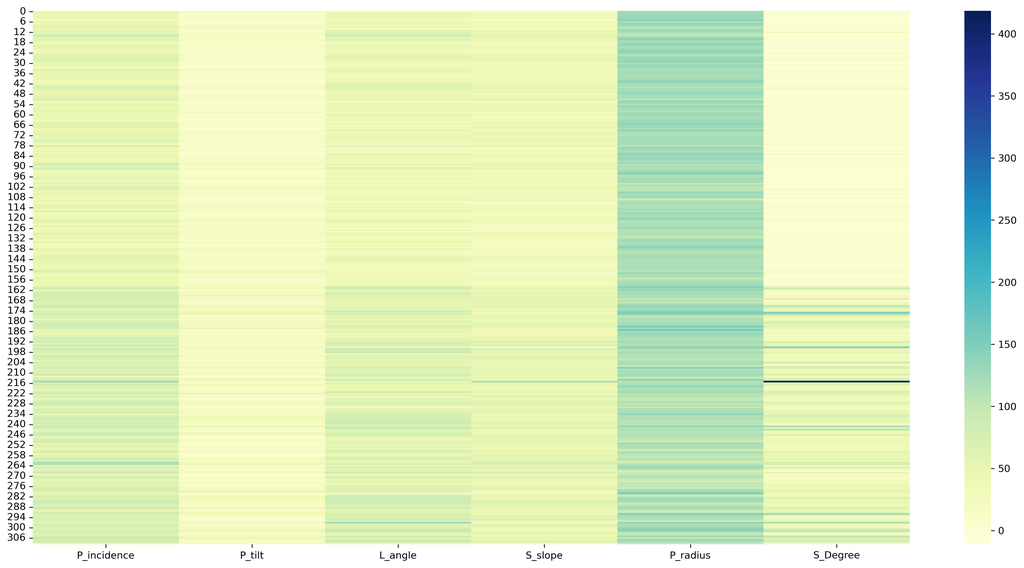

```python
plt.figure(figsize = (20,10),dpi = 300) # Intiziling the Plot size
sns.heatmap(df1,cmap="YlGnBu") #using seaborn ploting a heatmap with cmap
plt.show()
```

### Part 1.3 b - Share insights on correlation

#### B. Features having weaker correlation with correlation value.

The P-tilt as a Weaker correlation with the Values&

the values 0 - 156 in S_Degree also as a very weak correlation.

### Part 1.3 c - Visualize a pairplot with 3 classes distinguished by colors and share insights

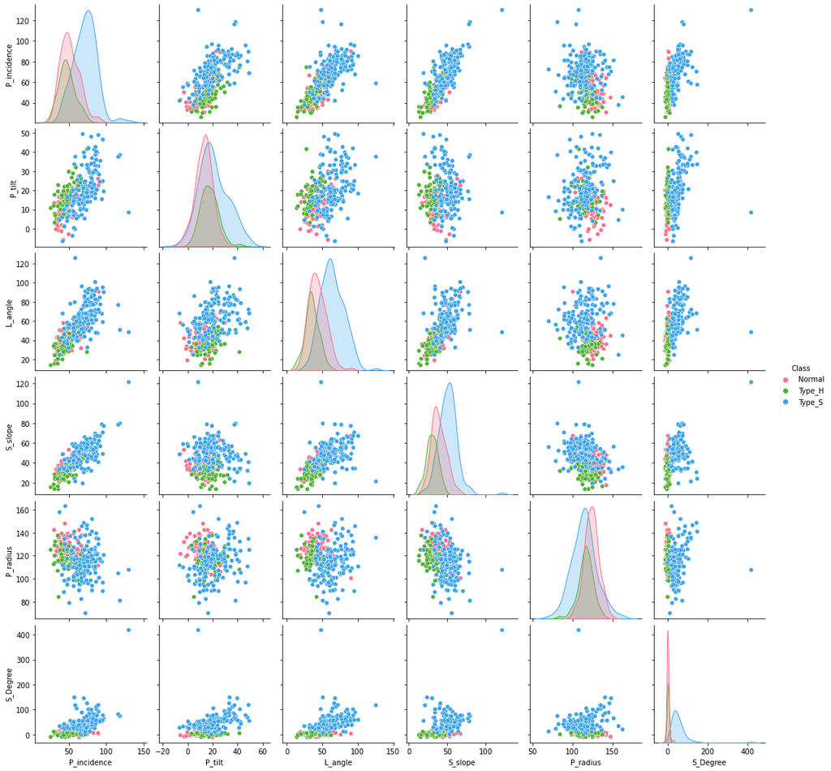

```python
plt.figure(dpi = 300) # Intiziling the Plot size
sns.pairplot(df,hue='Class',palette = 'husl' ) # Using Seaborn Pairplot ploting the Dataframe separate by Class
plt.show()
```

### Insights

1. From the Above Pair Plot for the DataFrame all the diagnol are under normal Distribution execept for S_Degree
2. P_incidence as Positive Correlation between P_tilt', 'L_angle', 'S_slope' with each other
3. The correlation bewteen P_radius and other variables are the data always densed at center
4. The S_Degree as minmun correlation between the other variables.

### Part 1.3 d - Visualize a jointplot for ‘P_incidence’ and ‘S_slope’ and share insights

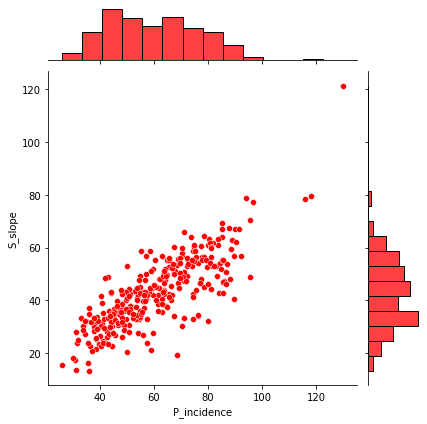

```python
plt.figure(figsize = (10,7),dpi=300) # Intiziling the Plot size
sns.jointplot(data = df,x ='P_incidence',y='S_slope',color='r')#ploting joint plot between P_incidence' and 'S_slope'
plt.show()
```

### Insights

1. From the Above Pair Plot Visualization, its Clear that the Variable 'P_incidence' and 'S_slope' follows Postive correlation.
2. The Marginial Distribustion of both the Variables are Right Skewed.
3. And the Data Also as some Outliers

### Part 1.3 e - Visualize a boxplot to check distribution of the features and share insights.

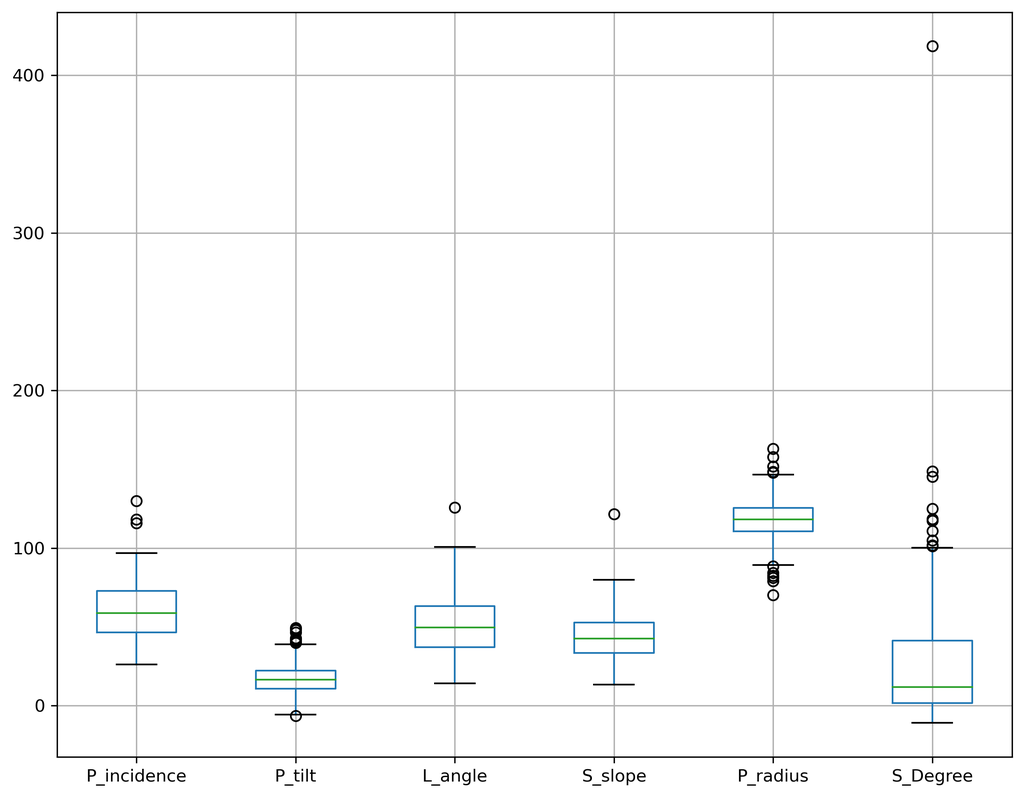

```python
plt.figure(figsize = (10,8),dpi = 300) # Intiziling the Plot size
boxplot = df.boxplot(column=['P_incidence', 'P_tilt', 'L_angle', 'S_slope', 'P_radius', 'S_Degree']) #PairPlot of the Dataframe
```

### Dealing Outliers

```python
col = df.columns[:-1].tolist()
for c in col:
    #getting upper lower quartile values
    q25,q75=np.percentile(df[c],25),np.percentile(df[c],75)
    IQR=q75-q25
    Threshold=IQR*1.5
    lower,upper=q25-Threshold,q75+Threshold


    Outliers=[i for i in df[c] if i < lower or i > upper]
    print('{} Total Number of outliers in {} Before Imputing : {}'.format('\033[1m',c,len(Outliers)))
    print('\n')

    #taking mean of a column without considering outliers
    df_include = df.loc[(df[c] >= lower) & (df[c] <= upper)]
    mean=int(df_include[c].mean())
    print('{} Mean of {} is {}'.format('\033[1m',c,mean))
    print('\n')

    #imputing outliers with mean
    df[c]=np.where(df[c]>upper,mean,df[c])
    df[c]=np.where(df[c]<lower,mean,df[c])
    Outliers=[i for i in df[c] if i < lower or i > upper]
    print('{} Total Number of outliers in {} After Imputing : {}'.format('\033[1m',c,len(Outliers)))
    print('\n')
```

```
 Total Number of outliers in P_incidence Before Imputing : 3


 Mean of P_incidence is 59


 Total Number of outliers in P_incidence After Imputing : 0


 Total Number of outliers in P_tilt Before Imputing : 13


 Mean of P_tilt is 16


 Total Number of outliers in P_tilt After Imputing : 0


 Total Number of outliers in L_angle Before Imputing : 1


 Mean of L_angle is 51


 Total Number of outliers in L_angle After Imputing : 0


 Total Number of outliers in S_slope Before Imputing : 1


 Mean of S_slope is 42


 Total Number of outliers in S_slope After Imputing : 0


 Total Number of outliers in P_radius Before Imputing : 11


 Mean of P_radius is 118


 Total Number of outliers in P_radius After Imputing : 0


 Total Number of outliers in S_Degree Before Imputing : 10


 Mean of S_Degree is 22


 Total Number of outliers in S_Degree After Imputing : 0
```

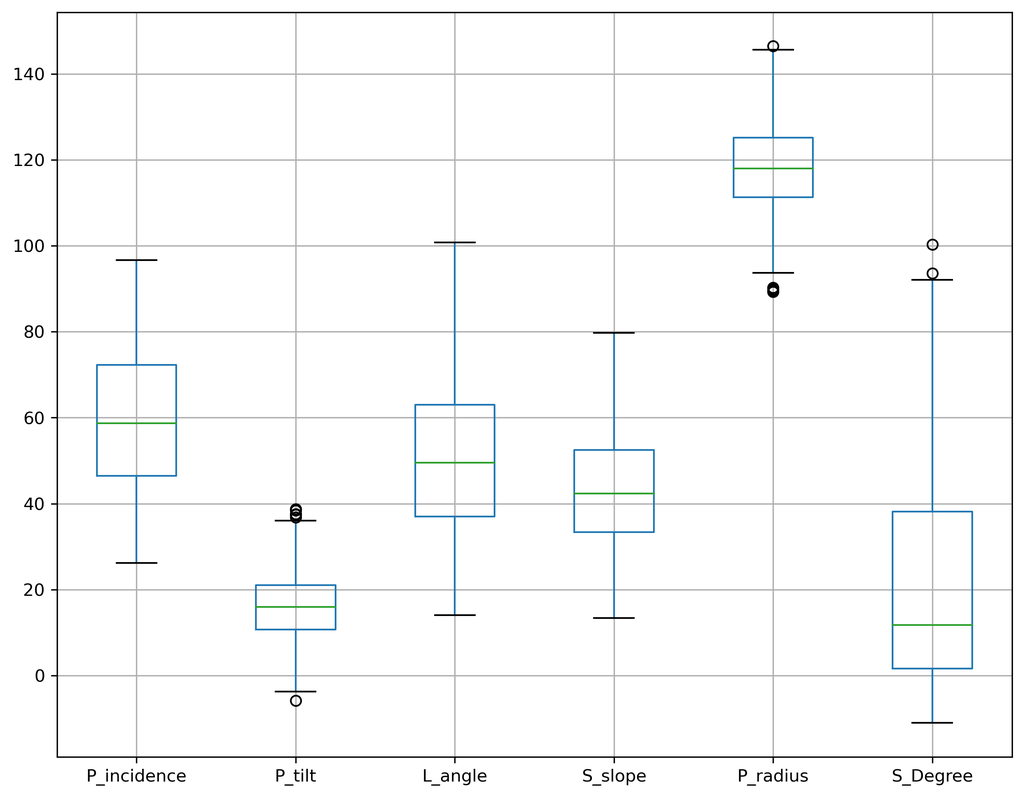

```python
plt.figure(figsize = (10,8),dpi = 300) # Intiziling the Plot size
boxplot = df.boxplot(column=['P_incidence', 'P_tilt', 'L_angle', 'S_slope', 'P_radius', 'S_Degree'])
```

## 4. Model Building:

### Part 1.4 a - Split data into X and Y.

```python
from sklearn.model_selection import train_test_split # import in train test and split model
from sklearn.neighbors import KNeighborsClassifier # import KNN Classifier
from scipy.stats import zscore #import Zscore for scipy
from sklearn import metrics #import mertics
from sklearn.metrics import confusion_matrix,classification_report
```

```python
df.dtypes #Datatype of all the Variables
```

```
P_incidence    float64
P_tilt         float64
L_angle        float64
S_slope        float64
P_radius       float64
S_Degree       float64
Class           object
dtype: object
```

The Class Variable is in 'object' Datatype so convert into 'category' Data Type

```python
df['Class'] = df.Class.astype('category') # Changing the Datatype of Variable class for object to Category
```

```python
df.dtypes #Datatype of all the Variables
```

```
P_incidence     float64
P_tilt          float64
L_angle         float64
S_slope         float64
P_radius        float64
S_Degree        float64
Class          category
dtype: object
```

```python
df.describe().T #description of the dataframe
```

|  | count | mean | std | min | 25% | 50% | 75% | max |
| --- | --- | --- | --- | --- | --- | --- | --- | --- |
| P_incidence | 310.0 | 59.893743 | 16.139975 | 26.147921 | 46.430294 | 58.691038 | 72.313279 | 96.657315 |
| P_tilt | 310.0 | 16.548519 | 8.404101 | -5.845994 | 10.705426 | 16.000000 | 21.021167 | 38.750670 |
| L_angle | 310.0 | 51.689825 | 18.071145 | 14.000000 | 37.000000 | 49.562398 | 62.964777 | 100.744220 |
| S_slope | 310.0 | 42.697607 | 12.656481 | 13.366931 | 33.347122 | 42.349084 | 52.475365 | 79.695154 |
| P_radius | 310.0 | 118.061242 | 11.342178 | 89.307547 | 111.295804 | 118.000000 | 125.196027 | 146.466001 |
| S_Degree | 310.0 | 22.193516 | 25.230932 | -11.058179 | 1.603727 | 11.767934 | 38.144544 | 100.292107 |

```python
X = df.drop('Class',axis =1) # Spliting X from Data frame with Class Variable (Independent Variables)
y = df['Class'] # Spliting y from Data Frame with Class Variable (dependent Variables)
```

```python
Xscaled = X.apply(zscore) #apply Zscore to normalize the Data

Xscaled.describe().T
```

|  | count | mean | std | min | 25% | 50% | 75% | max |
| --- | --- | --- | --- | --- | --- | --- | --- | --- |
| P_incidence | 310.0 | -6.159947e-17 | 1.001617 | -2.094203 | -0.835517 | -0.074638 | 0.770733 | 2.281479 |
| P_tilt | 310.0 | 5.241663e-17 | 1.001617 | -2.669021 | -0.696391 | -0.065374 | 0.533059 | 2.646095 |
| L_angle | 310.0 | 1.876635e-16 | 1.001617 | -2.089008 | -0.814203 | -0.117915 | 0.624929 | 2.718904 |
| S_slope | 310.0 | -2.438909e-16 | 1.001617 | -2.321190 | -0.739985 | -0.027582 | 0.773799 | 2.927936 |
| P_radius | 310.0 | -8.022257e-16 | 1.001617 | -2.539211 | -0.597449 | -0.005408 | 0.630066 | 2.508397 |
| S_Degree | 310.0 | -1.130816e-16 | 1.001617 | -1.320025 | -0.817373 | -0.413874 | 0.633223 | 3.100356 |

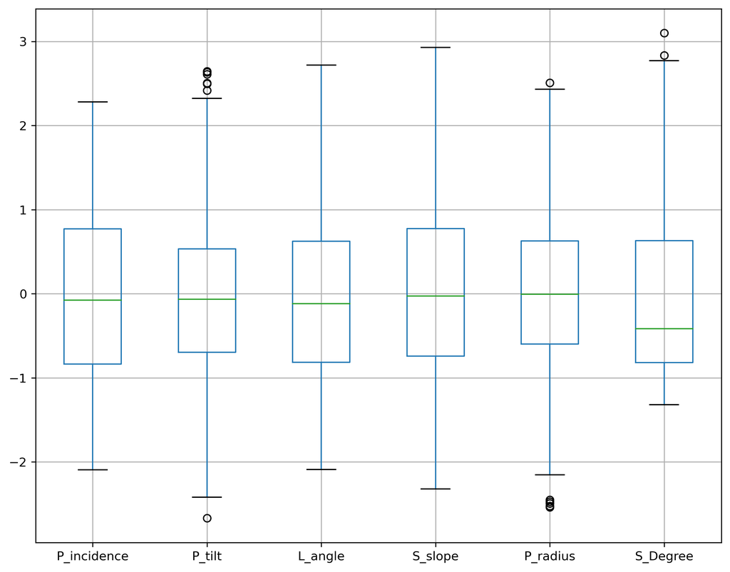

```python
plt.figure(figsize = (10,8),dpi = 300) # Intiziling the Plot size
boxplot = Xscaled.boxplot(column=['P_incidence', 'P_tilt', 'L_angle', 'S_slope', 'P_radius', 'S_Degree'])
```

### Part 1.4 b - Split data into train and test with 80:20 proportion

```python
Xtrain,Xtest,ytrain,ytest= train_test_split(Xscaled,y,test_size = 0.20,random_state=1) # Spliting X and y as Training and Test Dataset with 80:20 proportion
```

```python
model = KNeighborsClassifier(5, weights = 'distance') #creating Instance of KNN classifier with neighbors value as 5 and weight in distance
model.fit(Xtrain,ytrain) #fit the training data set in KNN model

class_predict = model.predict(Xtest) # Predcting the Class by using Precdict function in KNN ML Model by passing Xtest data
test_score = model.score(Xtest,ytest) #calculating the R2 score of training Data set
train_score = model.score(Xtrain,ytrain) #calculating the R2 score of testing Data set
```

```
Confusion Matrix:
```

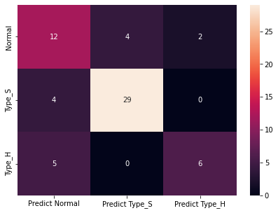

```python
print("Confusion Matrix:")
cm=metrics.confusion_matrix(ytest, class_predict, labels=["Normal","Type_S", "Type_H"]) # forming Confustion Matrix for Sklearn Metrics
df_cm = pd.DataFrame(cm, index = [i for i in ["Normal","Type_S", "Type_H"]],
                  columns = [i for i in ["Predict Normal","Predict Type_S","Predict Type_H"]])
plt.figure(figsize = (7,5))
sns.heatmap(df_cm, annot=True)
```

### Part 1.4 d - Print all the possible performance metrics for both train and test data

```python
print('Classification Report:\n',classification_report(ytest,class_predict))
print('Train Data Accuracy  Score:',train_score)
print('Test Data Accuracy  Score:',test_score)
print('Accuracy Score:',metrics.accuracy_score(ytest, class_predict))
```

```
Classification Report:
               precision    recall  f1-score   support

      Normal       0.57      0.67      0.62        18
      Type_H       0.75      0.55      0.63        11
      Type_S       0.88      0.88      0.88        33

    accuracy                           0.76        62
   macro avg       0.73      0.70      0.71        62
weighted avg       0.77      0.76      0.76        62

Train Data Accuracy  Score: 1.0
Test Data Accuracy  Score: 0.7580645161290323
Accuracy Score: 0.7580645161290323
```

### Part 1.5 a - Experiment with various parameters to improve performance of the base model

```python
model = KNeighborsClassifier(1, weights = 'distance') #creating Instance of KNN classifier with neighbors value as 5 and weight in distance
model.fit(Xtrain,ytrain) #fit the training data set in KNN model

class_predict = model.predict(Xtest) # Predcting the Class by using Precdict function in KNN ML Model by passing Xtest data
test_score = model.score(Xtest,ytest) #calculating the R2 score of training Data set
train_score = model.score(Xtrain,ytrain) #calculating the R2 score of testing Data set

print('Classification Report:\n',classification_report(ytest,class_predict))
print('Train Data Accuracy Score:',train_score)
print('Test Data Accuracy Score:',test_score)
print('Accuracy Score:',metrics.accuracy_score(ytest, class_predict))
```

```
Classification Report:
               precision    recall  f1-score   support

      Normal       0.71      0.83      0.77        18
      Type_H       0.73      0.73      0.73        11
      Type_S       0.93      0.85      0.89        33

    accuracy                           0.82        62
   macro avg       0.79      0.80      0.80        62
weighted avg       0.83      0.82      0.83        62

Train Data Accuracy Score: 1.0
Test Data Accuracy Score: 0.8225806451612904
Accuracy Score: 0.8225806451612904
```

```
The Accuaracy Scoure for K = 1 is 0.82
The Accuaracy Scoure for K = 2 is 0.74
The Accuaracy Scoure for K = 3 is 0.77
The Accuaracy Scoure for K = 4 is 0.71
The Accuaracy Scoure for K = 5 is 0.74
The Accuaracy Scoure for K = 6 is 0.74
The Accuaracy Scoure for K = 7 is 0.77
The Accuaracy Scoure for K = 8 is 0.73
The Accuaracy Scoure for K = 9 is 0.73
The Accuaracy Scoure for K = 10 is 0.73
The Accuaracy Scoure for K = 11 is 0.74
The Accuaracy Scoure for K = 12 is 0.74
The Accuaracy Scoure for K = 13 is 0.74
The Accuaracy Scoure for K = 14 is 0.74
The Accuaracy Scoure for K = 15 is 0.76
The Accuaracy Scoure for K = 16 is 0.74
The Accuaracy Scoure for K = 17 is 0.76
The Accuaracy Scoure for K = 18 is 0.77
The Accuaracy Scoure for K = 19 is 0.76
The Accuaracy Scoure for K = 20 is 0.76
The Accuaracy Scoure for K = 21 is 0.76
The Accuaracy Scoure for K = 22 is 0.76
The Accuaracy Scoure for K = 23 is 0.74
The Accuaracy Scoure for K = 24 is 0.76
The Accuaracy Scoure for K = 25 is 0.74
The Accuaracy Scoure for K = 26 is 0.74
The Accuaracy Scoure for K = 27 is 0.74
The Accuaracy Scoure for K = 28 is 0.74
The Accuaracy Scoure for K = 29 is 0.74
The Accuaracy Scoure for K = 30 is 0.74
The Accuaracy Scoure for K = 31 is 0.74
The Accuaracy Scoure for K = 32 is 0.73
The Accuaracy Scoure for K = 33 is 0.73
The Accuaracy Scoure for K = 34 is 0.73
The Accuaracy Scoure for K = 35 is 0.73
The Accuaracy Scoure for K = 36 is 0.73
The Accuaracy Scoure for K = 37 is 0.74
The Accuaracy Scoure for K = 38 is 0.73
The Accuaracy Scoure for K = 39 is 0.74
The Accuaracy Scoure for K = 40 is 0.74
The Accuaracy Scoure for K = 41 is 0.74
The Accuaracy Scoure for K = 42 is 0.74
The Accuaracy Scoure for K = 43 is 0.74
The Accuaracy Scoure for K = 44 is 0.73
The Accuaracy Scoure for K = 45 is 0.76
The Accuaracy Scoure for K = 46 is 0.69
The Accuaracy Scoure for K = 47 is 0.74
The Accuaracy Scoure for K = 48 is 0.73
The Accuaracy Scoure for K = 49 is 0.76
The Accuaracy Scoure for K = 50 is 0.74
```

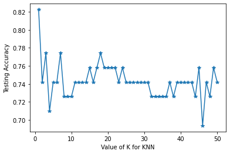

```python
k_range = range(1,51)

score =[]

for k in k_range:
    knn = KNeighborsClassifier(n_neighbors=k, metric = 'euclidean')
    knn.fit(Xtrain,ytrain)
    ypred = knn.predict(Xtest)
    score.append(metrics.accuracy_score(ytest,ypred))

for i in k_range:
    print ("The Accuaracy Scoure for K = {} is {}".format(i,round(score[i-1],2)))



plt.plot(k_range, score,'*-')
plt.xlabel('Value of K for KNN')
plt.ylabel('Testing Accuracy')
```

```
The Accuaracy Scoure for K = 1 is 0.82
The Accuaracy Scoure for K = 2 is 0.74
The Accuaracy Scoure for K = 3 is 0.77
The Accuaracy Scoure for K = 4 is 0.71
The Accuaracy Scoure for K = 5 is 0.74
The Accuaracy Scoure for K = 6 is 0.74
The Accuaracy Scoure for K = 7 is 0.77
The Accuaracy Scoure for K = 8 is 0.73
The Accuaracy Scoure for K = 9 is 0.73
The Accuaracy Scoure for K = 10 is 0.73
The Accuaracy Scoure for K = 11 is 0.74
The Accuaracy Scoure for K = 12 is 0.74
The Accuaracy Scoure for K = 13 is 0.74
The Accuaracy Scoure for K = 14 is 0.74
The Accuaracy Scoure for K = 15 is 0.76
The Accuaracy Scoure for K = 16 is 0.74
The Accuaracy Scoure for K = 17 is 0.76
The Accuaracy Scoure for K = 18 is 0.77
The Accuaracy Scoure for K = 19 is 0.76
The Accuaracy Scoure for K = 20 is 0.76
```

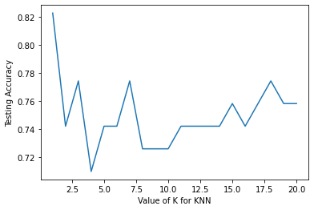

```python
k_range = range(1,21)

score =[]

for k in k_range:
    knn = KNeighborsClassifier(n_neighbors=k, metric = 'euclidean')
    knn.fit(Xtrain,ytrain)
    ypred = knn.predict(Xtest)
    score.append(metrics.accuracy_score(ytest,ypred))

for i in k_range:
    print ("The Accuaracy Scoure for K = {} is {}".format(i,round(score[i-1],2)))



plt.plot(k_range, score)
plt.xlabel('Value of K for KNN')
plt.ylabel('Testing Accuracy')
```

### Part 1.5 b - Clearly showcase improvement in performance achieved

The K Value 1 Give a Higher Accuary rate but we cannot take it for the consideration becase the dataset get bias

### Part 1.5 c - Clearly state which parameters contributed most to improve model performance.

All the variables has significant effect on target class

class belongs to type_s has higher mean value for alomst all variables

For almost all variables the distribution is normal

# Part B

### Part 2.1 a - Read both the Datasets ‘Data1’ and ‘Data 2’ as DataFrame and store them into two separate variables

```python
data1 = pd.read_csv('Data1.csv') #Reading Data1 CSV as data1 Dataframe Using Pandas read function
data2 = pd.read_csv('Data2.csv') #Reading Data2 CSV as data2 Dataframe Using Pandas read function
```

### Part 2.1 b - Print shape and Column Names and DataTypes of both the Dataframes.

```python
data1_shape = data1.shape # Getting Shape of data 1 and assigning to the data1_shape Variable
data2_shape = data2.shape # Getting Shape of data 2 and assigning to the data2_shape Variable
data1_cols = data1.columns.tolist() # Getting columns Names of data 1 and assigning to the data1_cols Variable
data2_cols = data2.columns.tolist() # Getting columns Names of data 2 and assigning to the data2_cols Variable
data1_dtyp = data1.dtypes # Getting Datatypes of all the columns in data 1 and assigning to the data1_dtyp Variable
data2_dtyp = data2.dtypes # Getting Datatypes of all the columns in data 2 and assigning to the data2_dtyp Variable

print ('\033[1mShape:\033[0m\nThe Number of Rows and Columns in the DataFrame Data1 is: \033[1m{}\033[0m\nThe Number of Rows and columns in the DataFrame Data1 is: \033[1m{}\033[m'.format(data1_shape,data2_shape)) #printing Shape values
print ('\n\033[1mColumn Names:\033[0m  \nThe Column Names in the DataFrame Data1 is: \033[1m\n{}\033[0m\n\nThe Column Names in the DataFrame Data1 is: \033[1m\n{}\033[0m'.format(data1_cols,data2_cols)) #Printing column Name
print ('\n\033[1mData Types :\033[0m\n The Data Types in Data 1 DataFrame\033[1m\n{}\033[0m\n\n The Data Types in Data 2 DataFrame\033[1m\n{}\033[0m'.format(data1_dtyp,data2_dtyp)) #printing Datatypes in the dataframes
```

```
Shape:
The Number of Rows and Columns in the DataFrame Data1 is: (5000, 8)
The Number of Rows and columns in the DataFrame Data1 is: (5000, 7)

Column Names:
The Column Names in the DataFrame Data1 is:
['ID', 'Age', 'CustomerSince', 'HighestSpend', 'ZipCode', 'HiddenScore', 'MonthlyAverageSpend', 'Level']

The Column Names in the DataFrame Data1 is:
['ID', 'Mortgage', 'Security', 'FixedDepositAccount', 'InternetBanking', 'CreditCard', 'LoanOnCard']

Data Types :
 The Data Types in Data 1 DataFrame
ID                       int64
Age                      int64
CustomerSince            int64
HighestSpend             int64
ZipCode                  int64
HiddenScore              int64
MonthlyAverageSpend    float64
Level                    int64
dtype: object

 The Data Types in Data 2 DataFrame
ID                       int64
Mortgage                 int64
Security                 int64
FixedDepositAccount      int64
InternetBanking          int64
CreditCard               int64
LoanOnCard             float64
dtype: object
```

### Part 2.1 c - Merge both the Dataframes on ‘ID’ feature to form a single DataFrame

```python
bank_df = pd.merge(data1,data2, on='ID') #Creating new dataframe using pandas merge function merge on ID Columns
bank_df
```

|  | ID | Age | CustomerSince | HighestSpend | ZipCode | HiddenScore | MonthlyAverageSpend | Level | Mortgage | Security | FixedDepositAccount | InternetBanking | CreditCard | LoanOnCard |
| --- | --- | --- | --- | --- | --- | --- | --- | --- | --- | --- | --- | --- | --- | --- |
| 0 | 1 | 25 | 1 | 49 | 91107 | 4 | 1.6 | 1 | 0 | 1 | 0 | 0 | 0 | NaN |
| 1 | 2 | 45 | 19 | 34 | 90089 | 3 | 1.5 | 1 | 0 | 1 | 0 | 0 | 0 | NaN |
| 2 | 3 | 39 | 15 | 11 | 94720 | 1 | 1.0 | 1 | 0 | 0 | 0 | 0 | 0 | NaN |
| 3 | 4 | 35 | 9 | 100 | 94112 | 1 | 2.7 | 2 | 0 | 0 | 0 | 0 | 0 | NaN |
| 4 | 5 | 35 | 8 | 45 | 91330 | 4 | 1.0 | 2 | 0 | 0 | 0 | 0 | 1 | NaN |
| ... | ... | ... | ... | ... | ... | ... | ... | ... | ... | ... | ... | ... | ... | ... |
| 4995 | 4996 | 29 | 3 | 40 | 92697 | 1 | 1.9 | 3 | 0 | 0 | 0 | 1 | 0 | 0.0 |
| 4996 | 4997 | 30 | 4 | 15 | 92037 | 4 | 0.4 | 1 | 85 | 0 | 0 | 1 | 0 | 0.0 |
| 4997 | 4998 | 63 | 39 | 24 | 93023 | 2 | 0.3 | 3 | 0 | 0 | 0 | 0 | 0 | 0.0 |
| 4998 | 4999 | 65 | 40 | 49 | 90034 | 3 | 0.5 | 2 | 0 | 0 | 0 | 1 | 0 | 0.0 |
| 4999 | 5000 | 28 | 4 | 83 | 92612 | 3 | 0.8 | 1 | 0 | 0 | 0 | 1 | 1 | 0.0 |

5000 rows × 14 columns

### Part 2.1 d - Change Datatype of below features to ‘Object’

```python
var = ['CreditCard', 'InternetBanking', 'FixedDepositAccount', 'Security', 'Level', 'HiddenScore']
bank_df[var] = bank_df[var].astype('object')
```

```python
bank_df.dtypes
```

```
ID                       int64
Age                      int64
CustomerSince            int64
HighestSpend             int64
ZipCode                  int64
HiddenScore             object
MonthlyAverageSpend    float64
Level                   object
Mortgage                 int64
Security                object
FixedDepositAccount     object
InternetBanking         object
CreditCard              object
LoanOnCard             float64
dtype: object
```

### Part 2.2 a - Visualize distribution of Target variable ‘LoanOnCard’ and clearly share insights

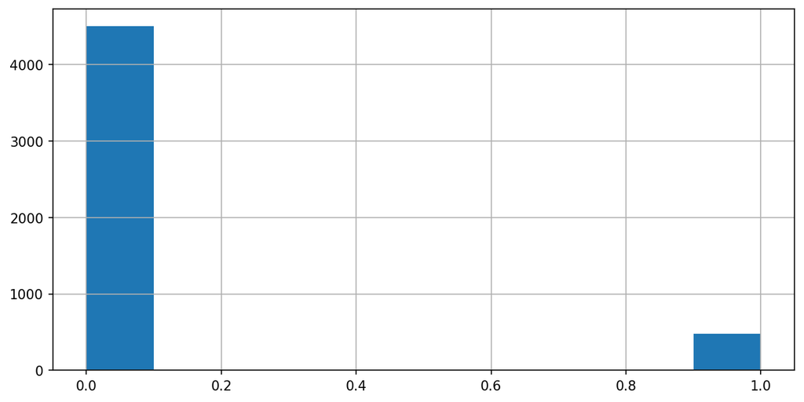

```python
plt.figure(figsize=(10,5),dpi = 150) #Graph Figure Siz and DPI
bank_df['LoanOnCard'].hist() #histogram of LoanOn Card
plt.show()
```

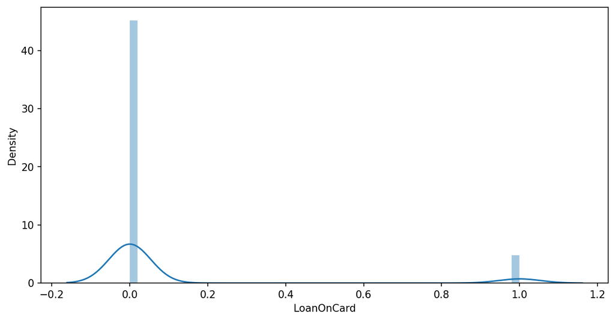

```python
plt.figure(figsize=(10,5),dpi = 150) #Graph Figure Siz and DPI
sns.distplot(bank_df['LoanOnCard'],kde = True) # ploting Displot on LoanOnCard with KDE
plt.show()
```

### Observation :

The Variable 'LoanOnCard' in the DataFrame is floating data type with values 0 and 1

### Part 2.2 b - Check the percentage of missing values and impute if required

```python
bank_df.isnull().sum() # Checking for the Null Values
```

```
ID                      0
Age                     0
CustomerSince           0
HighestSpend            0
ZipCode                 0
HiddenScore             0
MonthlyAverageSpend     0
Level                   0
Mortgage                0
Security                0
FixedDepositAccount     0
InternetBanking         0
CreditCard              0
LoanOnCard             20
dtype: int64
```

```python
for i,cols in enumerate(bank_df.columns):
    print ('The Percentage of Missing Value in \033[1m{}\033[0m is \033[1m{}\033[0m'.format(cols,bank_df[cols].isnull().sum()/bank_df[cols].shape[0]))
```

```
The Percentage of Missing Value in ID is 0.0
The Percentage of Missing Value in Age is 0.0
The Percentage of Missing Value in CustomerSince is 0.0
The Percentage of Missing Value in HighestSpend is 0.0
The Percentage of Missing Value in ZipCode is 0.0
The Percentage of Missing Value in HiddenScore is 0.0
The Percentage of Missing Value in MonthlyAverageSpend is 0.0
The Percentage of Missing Value in Level is 0.0
The Percentage of Missing Value in Mortgage is 0.0
The Percentage of Missing Value in Security is 0.0
The Percentage of Missing Value in FixedDepositAccount is 0.0
The Percentage of Missing Value in InternetBanking is 0.0
The Percentage of Missing Value in CreditCard is 0.0
The Percentage of Missing Value in LoanOnCard is 0.004
```

```python
bank_df['LoanOnCard'] = bank_df['LoanOnCard'].fillna(0)
```

```python
bank_df.isnull().sum()
```

```
ID                     0
Age                    0
CustomerSince          0
HighestSpend           0
ZipCode                0
HiddenScore            0
MonthlyAverageSpend    0
Level                  0
Mortgage               0
Security               0
FixedDepositAccount    0
InternetBanking        0
CreditCard             0
LoanOnCard             0
dtype: int64
```

### Part 2.2 c - Check for unexpected values in each categorical variable and impute with best suitable value.

```python
for i,vars in enumerate(var):
    print(vars ,bank_df[vars].unique())
```

```
CreditCard [0 1]
InternetBanking [0 1]
FixedDepositAccount [0 1]
Security [1 0]
Level [1 2 3]
HiddenScore [4 3 1 2]
```

```python
bank_df.dtypes
```

```
ID                       int64
Age                      int64
CustomerSince            int64
HighestSpend             int64
ZipCode                  int64
HiddenScore             object
MonthlyAverageSpend    float64
Level                   object
Mortgage                 int64
Security                object
FixedDepositAccount     object
InternetBanking         object
CreditCard              object
LoanOnCard             float64
dtype: object
```

### Part 2.3 a- Split data into X and Y

```python
from sklearn.model_selection import train_test_split
from sklearn.linear_model import LogisticRegression
from sklearn import metrics
```

```python
X = bank_df.drop(['ID','ZipCode','LoanOnCard'],axis = 1)
y = bank_df['LoanOnCard']
```

### Part 2.3 b - Split data into train and test. Keep 25% data reserved for testing

```python
Xtrain,Xtest,ytrain,ytest = train_test_split(X,y,test_size=0.25,random_state=1)
```

### Part 2.3 c - Train a Supervised Learning Classification base model - Logistic Regression

```python
logistic_model = LogisticRegression(solver='liblinear')
logistic_model.fit(Xtrain,ytrain)
```

```
LogisticRegression(solver='liblinear')
```

```python
logistic_model.score(Xtest,ytest)
```

```
0.9448
```

```python
ypredict = logistic_model.predict(Xtest)
```

### Part 2.3 d - Print evaluation metrics for the model and clearly share insights.

[figure not shown]

```python
cm = metrics.confusion_matrix(ytest,ypredict)
df_cm = pd.DataFrame(cm, index = [i for i in ["1","0"]],
                  columns = [i for i in ["Predict 1","Predict 0"]])
plt.figure(figsize = (7,5))
sns.heatmap(df_cm, annot=True,fmt='g')
plt.show()
```

```python
print (y.value_counts())
print(metrics.accuracy_score(ytest,ypredict))
print(metrics.classification_report(ytest,ypredict))
```

```
0.0    4520
1.0     480
Name: LoanOnCard, dtype: int64
0.9448
              precision    recall  f1-score   support

         0.0       0.95      0.99      0.97      1121
         1.0       0.83      0.59      0.69       129

    accuracy                           0.94      1250
   macro avg       0.89      0.79      0.83      1250
weighted avg       0.94      0.94      0.94      1250
```

```python
print('The Accuracy Score is :',metrics.accuracy_score(ytest,ypredict))
```

```
The Accuracy Score is : 0.9448
```

### Part 2.3 e - Balance the data using the right balancing technique.

### We Balanacing Target data Through Under and Over Sampling Methods

#### Under sampling

Random Under sampling

ClusterCentroids

#### over sampling

Random Over sampling

SMOTE

### Under Sampling : Random Under Sampling

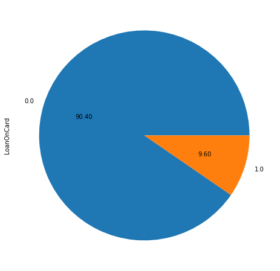

```python
plt.figure(figsize = (8,8))
bank_df['LoanOnCard'].value_counts().plot.pie(autopct ='%.2f')
plt.show()
```

### In the Given Data Set the Target variable "Loanoncards" as 90.40% as 0's and 9.6 are l's

For this type of data set we are using Imbalance Data Model to redue the imbalance in the Data Set

```python
from imblearn.under_sampling import RandomUnderSampler

us = RandomUnderSampler(random_state=1)


x_us,y_us = us.fit_resample(X,y)

Xtrain_us,Xtest_us,ytrain_us,ytest_us=train_test_split(x_us,y_us,test_size=0.25,random_state=1)

lr_us = LogisticRegression(solver='liblinear')
lr_us.fit(Xtrain_us,ytrain_us)


yp_us = lr_us.predict(Xtest_us)

print(y_us.value_counts())
print(metrics.classification_report(ytest_us,yp_us))
```

```
0.0    480
1.0    480
Name: LoanOnCard, dtype: int64
              precision    recall  f1-score   support

         0.0       0.89      0.87      0.88       117
         1.0       0.88      0.90      0.89       123

    accuracy                           0.89       240
   macro avg       0.89      0.89      0.89       240
weighted avg       0.89      0.89      0.89       240
```

### Cluster Centroids Approach

```python
from imblearn.under_sampling import ClusterCentroids

cc = ClusterCentroids(random_state=1)
```

```python
x_cc,y_cc = cc.fit_resample(X,y)

Xtrain_cc,Xtest_cc,ytrain_cc,ytest_cc=train_test_split(x_cc,y_cc,test_size=0.25,random_state=1)

lr_cc = LogisticRegression(solver='liblinear')
lr_cc.fit(Xtrain_cc,ytrain_cc)


yp_cc = lr_cc.predict(Xtest_cc)

print (y_cc.value_counts())
print (metrics.classification_report (ytest_cc,yp_cc))
```

```
0.0    480
1.0    480
Name: LoanOnCard, dtype: int64
              precision    recall  f1-score   support

         0.0       0.88      0.91      0.90       117
         1.0       0.92      0.89      0.90       123

    accuracy                           0.90       240
   macro avg       0.90      0.90      0.90       240
weighted avg       0.90      0.90      0.90       240
```

### Random Over Sampling

```python
from imblearn.over_sampling import RandomOverSampler

ros = RandomOverSampler(random_state =1)
```

```python
x_ros,y_ros = ros.fit_resample(X,y)

Xtrain_ros,Xtest_ros,ytrain_ros,ytest_ros=train_test_split(x_ros,y_ros,test_size=0.25,random_state=1)

lr_ros = LogisticRegression(solver='liblinear')
lr_ros.fit(Xtrain_ros,ytrain_ros)


yp_ros = lr_ros.predict(Xtest_ros)

print (y_ros.value_counts())
print(metrics.classification_report(ytest_ros,yp_ros))
```

```
0.0    4520
1.0    4520
Name: LoanOnCard, dtype: int64
              precision    recall  f1-score   support

         0.0       0.90      0.89      0.90      1114
         1.0       0.90      0.90      0.90      1146

    accuracy                           0.90      2260
   macro avg       0.90      0.90      0.90      2260
weighted avg       0.90      0.90      0.90      2260
```

## SMOTE

```python
from imblearn.over_sampling import SMOTE

smote = SMOTE(random_state=1)
```

```python
x_smote,y_smote = smote.fit_resample(X,y)

Xtrain_smote,Xtest_smote,ytrain_smote,ytest_smote=train_test_split(x_smote,y_smote,test_size=0.25,random_state=1)

lr_smote = LogisticRegression(solver='liblinear')
lr_smote.fit(Xtrain_smote,ytrain_smote)


yp_smote = lr_smote.predict(Xtest_smote)

print (y_smote.value_counts())
print(metrics.classification_report(ytest_smote,yp_smote))
```

```
0.0    4520
1.0    4520
Name: LoanOnCard, dtype: int64
              precision    recall  f1-score   support

         0.0       0.90      0.90      0.90      1114
         1.0       0.90      0.90      0.90      1146

    accuracy                           0.90      2260
   macro avg       0.90      0.90      0.90      2260
weighted avg       0.90      0.90      0.90      2260
```

### Part 2.3 g- Print evaluation metrics and clearly share differences observed

```python
print('The Accuracy Score of Random Under sample Method is :',metrics.accuracy_score(ytest_us,yp_us))
print('The Accuracy Score is Cluster Centroid Methos is:',metrics.accuracy_score(ytest_cc,yp_cc))
print('The Accuracy Score is Random Over Sample Method is:',metrics.accuracy_score(ytest_ros,yp_ros))
print('The Accuracy Score is SMOTE Method is :',metrics.accuracy_score(ytest_smote,yp_smote))
```

```
The Accuracy Score of Random Under sample Method is : 0.8875
The Accuracy Score is Cluster Centroid Methos is: 0.9
The Accuracy Score is Random Over Sample Method is: 0.897787610619469
The Accuracy Score is SMOTE Method is : 0.9013274336283186
```

Both SMOTE and ClusterCentroid Imbalace give 90 accuracy Scores

### Part 2.4 a- Train a base model each for SVM, KNN

```python
from sklearn import svm
from sklearn.svm import SVC
```

Applying Support Vector Classifier in SVM

```python
svc = svm.SVC(C=.1,kernel ='linear',gamma=1)
svc.fit(Xtrain,ytrain)

ypredict = svc.predict(Xtest)

print("The Accuarcy Score of Support Vector Classifier is:",metrics.accuracy_score(ytest,ypredict))
print('Classification Report:',classification_report(ytest,ypredict))
```

```
The Accuarcy Score of Support Vector Classifier is: 0.9504
Classification Report:               precision    recall  f1-score   support

         0.0       0.95      0.99      0.97      1121
         1.0       0.91      0.57      0.70       129

    accuracy                           0.95      1250
   macro avg       0.93      0.78      0.84      1250
weighted avg       0.95      0.95      0.95      1250
```

Applying KNN to the Traing and Testing data set

```python
knn = KNeighborsClassifier(n_neighbors=10,metric='euclidean')
knn.fit(Xtrain,ytrain)

ypred_knn = knn.predict(Xtest)

print ('The Accuracy Score of KNN is:',metrics.accuracy_score(ytest,ypred_knn))
print ("The Classification Report of KNN is:\n",classification_report(ytest,ypred_knn))
```

```
The Accuracy Score of KNN is: 0.9
The Classification Report of KNN is:
               precision    recall  f1-score   support

         0.0       0.92      0.98      0.95      1121
         1.0       0.54      0.21      0.30       129

    accuracy                           0.90      1250
   macro avg       0.73      0.59      0.62      1250
weighted avg       0.88      0.90      0.88      1250
```

### Part 2.4 b - Tune parameters for each of the models wherever required and finalize a mode

Apply the RBF kernel in the SVC

```python
svc = svm.SVC(C=1.0, kernel='rbf', degree=3, gamma='auto')
svc.fit(Xtrain,ytrain)

ypredict = svc.predict(Xtest)

print("The Accuarcy Score of Support Vector Classifier is:",metrics.accuracy_score(ytest,ypredict))
print('Classification Report:',classification_report(ytest,ypredict))
```

```
The Accuarcy Score of Support Vector Classifier is: 0.9024
Classification Report:               precision    recall  f1-score   support

         0.0       0.90      1.00      0.95      1121
         1.0       0.89      0.06      0.12       129

    accuracy                           0.90      1250
   macro avg       0.90      0.53      0.53      1250
weighted avg       0.90      0.90      0.86      1250
```

Applying SVC in Balanced Data Set Smote Method

```python
svc = svm.SVC(C=1.0, kernel='rbf', degree=3, gamma='auto')
svc.fit(Xtrain_smote,ytrain_smote)

ypredict = svc.predict(Xtest_smote)
acs=metrics.accuracy_score(ytest_smote,ypredict)
cr=metrics.classification_report(ytest_smote,ypredict)
print("The Accuarcy Score of Support Vector Classifier is:",acs)
print('Classification Report:',cr)
```

```
The Accuarcy Score of Support Vector Classifier is: 0.9287610619469027
Classification Report:               precision    recall  f1-score   support

         0.0       0.90      0.96      0.93      1114
         1.0       0.96      0.90      0.93      1146

    accuracy                           0.93      2260
   macro avg       0.93      0.93      0.93      2260
weighted avg       0.93      0.93      0.93      2260
```

```python
k_range= range(1,21)

score =[]
for i in k_range:
    KNN1 = KNeighborsClassifier(k,weights='distance')
    KNN1.fit(Xtrain_smote,ytrain_smote)
    ypred=KNN1.predict(Xtest_smote)
    score.append(metrics.accuracy_score(ytest_smote,ypred))

for i in k_range:
    print ("The Accuaracy Scoure for K = {} is {}".format(i,round(score[i-1],2)))
```

```
The Accuaracy Scoure for K = 1 is 0.91
The Accuaracy Scoure for K = 2 is 0.91
The Accuaracy Scoure for K = 3 is 0.91
The Accuaracy Scoure for K = 4 is 0.91
The Accuaracy Scoure for K = 5 is 0.91
The Accuaracy Scoure for K = 6 is 0.91
The Accuaracy Scoure for K = 7 is 0.91
The Accuaracy Scoure for K = 8 is 0.91
The Accuaracy Scoure for K = 9 is 0.91
The Accuaracy Scoure for K = 10 is 0.91
The Accuaracy Scoure for K = 11 is 0.91
The Accuaracy Scoure for K = 12 is 0.91
The Accuaracy Scoure for K = 13 is 0.91
The Accuaracy Scoure for K = 14 is 0.91
The Accuaracy Scoure for K = 15 is 0.91
The Accuaracy Scoure for K = 16 is 0.91
The Accuaracy Scoure for K = 17 is 0.91
The Accuaracy Scoure for K = 18 is 0.91
The Accuaracy Scoure for K = 19 is 0.91
The Accuaracy Scoure for K = 20 is 0.91
```

From the Above observations Applying SVC in Balanced Data Set Smote Method as higher accuary rate of 0.93

### Part 2.4 c- Print evaluation metrics for final mode

```python
print("The Accuarcy Score of Support Vector Classifier is:",acs)
print('Classification Report:',cr)
```

```
The Accuarcy Score of Support Vector Classifier is: 0.9287610619469027
Classification Report:               precision    recall  f1-score   support

         0.0       0.90      0.96      0.93      1114
         1.0       0.96      0.90      0.93      1146

    accuracy                           0.93      2260
   macro avg       0.93      0.93      0.93      2260
weighted avg       0.93      0.93      0.93      2260
```

### Part 2.4 d- Share improvement achieved from base model to final model

The The Accuracy Score of the Base model is 0.9448 but the dataset as unbalanced Data the "Loanoncards" target variable as 90.40% as 0's and 9.6 are l's the changes of bias is Higher